# Data Visualisation: Extension Exercises

Ben Whalley

September 2020

# Logarithmic scales

A common problem when plotting some types of data is dealing with extreme values, or skewed distributions. Income data and reaction times are two notable examples: both are typically highly skewed.

We already saw in first worksheet the `cps2` dataset that income is very unevenly distributed, and a small number of people earn *much* more than the average. This means a plot of income data can obscure interesting details around the median; the scale is forced to include extreme values, even though they represent very few people. This is obvious in the CPS2 data, even without including billionares like Jeff Bezos:

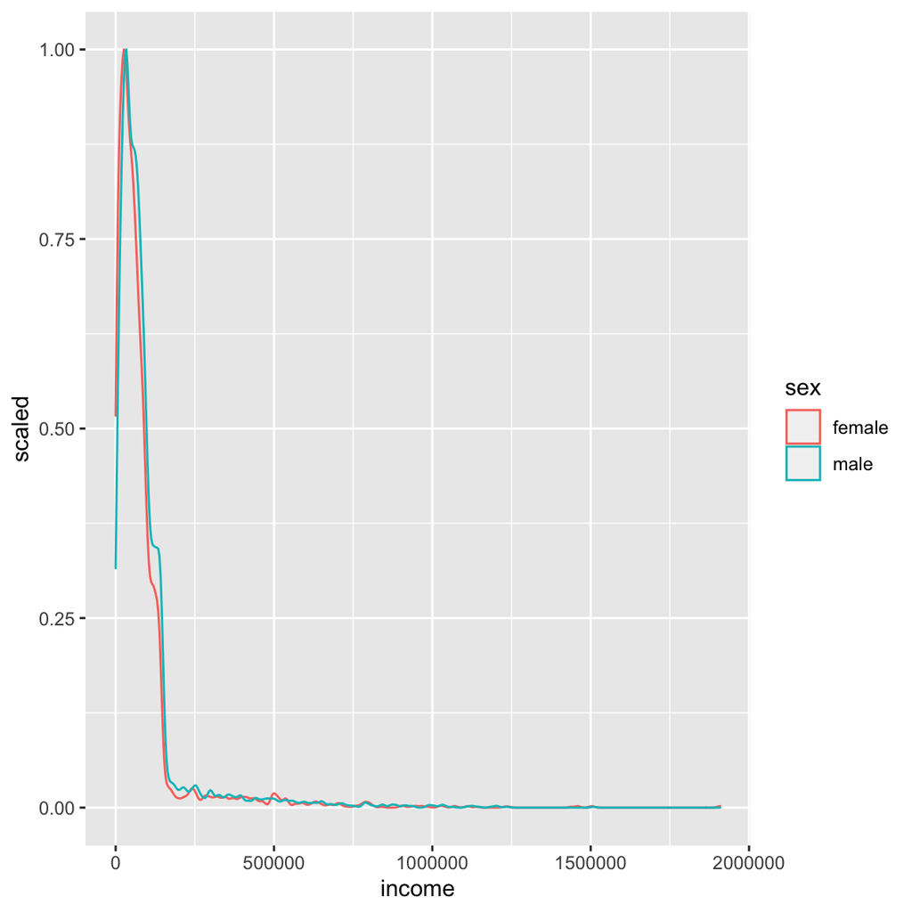

```r
cps2 <- read_csv('data/cps2.csv')
cps2  %>%
  ggplot(aes(income, color=sex, y=..scaled..)) + geom_density()
```

In the previous worksheet we dealt with this by using `filter` to remove cases where people earned more than $150000.

However there is another way to replot all of the data, but still see the gender pay gap: we can change the scale so that the units on the x axis are not evenly spaced: we can make it so that each marker represents an increasingly large difference:

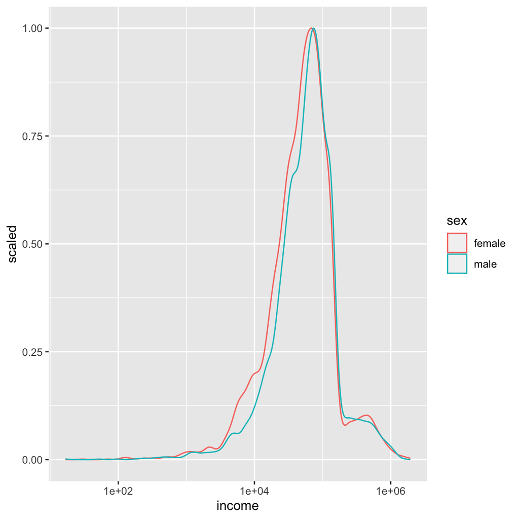

```r
cps2 %>%
  ggplot(aes(income, color=sex, y=..scaled..)) +
  geom_density() +
  scale_x_log10()
```

**Explanation of the output**: Two warnings may be shown about ‘infinite values’ and ‘removing non-finite values’; you can ignore these for now. The y axis of the graph has stayed the same, but the x axis has now changed. Rather than being equally-sized, the gaps in income represented by the gridlines are now uneven. Specifically, the difference between each vertical grid line is 10 times bigger than the previous one (you can find out [more about what `logn and log10` means here if you are interested](https://www.khanacademy.org/math/algebra2/x2ec2f6f830c9fb89:logs/x2ec2f6f830c9fb89:log-intro/v/logarithms)). R has (somewhat unhelpfully) switched to using [scientific notation](https://www.khanacademy.org/math/pre-algebra/pre-algebra-exponents-radicals/pre-algebra-scientific-notation/v/scientific-notation-old). This means that `1e+02` is equal to $1 \times$ 10^2$, or 100 to you an me. `1e+04` means $1 \times$ 10^4$, or 10,000, and so on. We can now see the gender pay gap much more clearly (as we also did when we simply filtered-out very high earners).

**Comments on interpreting the log-scaled graph**: Although the log scale helps us see the differences between men and women, we must remember that we are interpreting a log-scaled plot. You will notice that — in contrast to the previous plot where we simply removed very high earners — the gender differences in this plot are more obvious at lower levels of income, **even though the absolute size of the difference in dollars is just as large for high as for low earners**. This is an artefact of the plotting method because the scale is unevenly spaced: For a fixed difference in income between men and women (say $500) it will be easier to see at the bottom than at the top of the scale. Of course, the counter argument is that a $500 difference is *more important* if you earn less than $10,000 than if you earn > $200,000, so this extra emphasis is helpful. But there is no *correct* answer: the different plots emphasise different aspects of the data.

Use the `gapminder` dataset again.

1. Filter the data so you are only using observations from a single year
2. Plot GDP per capita (x axis) against life expectancy (y axis) using a normal scale for GDP.
3. Now replot using a log scale for GDP.
4. If it’s possible, discuss with others: what are the advantages of using a log scale in this instance? (if you are alone, perhaps make some notes on the pros and cons and have a discussion in the next session)

## Task 2: Use a log scale for reaction time data

This paper presents data on reaction times in a cross sectional sample of participants of different ages: https://journals.plos.org/plosone/article?id=10.1371/journal.pone.0189598#sec016

The data are available in Excel format from PlosOne, but I have provided a (tidied up) subset of the data here: subset of RT data.

1. Import this subset of the data, and recreate the scatterplot from Figure 1 in the paper (use `geom_smooth` for the lines, and don’t worry if the lines are not exactly the same).
2. Use the `scale_y_log10` command to adjust the scale of the Y axis. The result should look something like this:

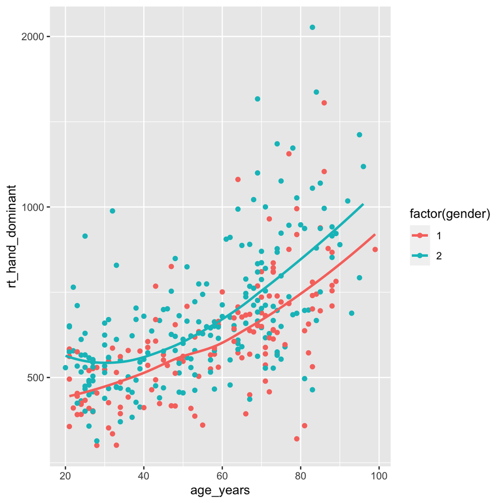

3. If you have time look at the help files for `scale_y_log10` (type `?scale_y_log10` into the console). See if you can work out how to change the years that are labelled on the x axis (the scale breaks or ‘ticks’). You may find the help files quite cryptic to begin with, but it’s often a good idea to check right down at the bottom of the document — there may be examples of usage shown there.

# Real world plotting

So far we have learned about `ggplot` and worked through lots of examples. You might have noticed though: we focused mostly on the technique and didn’t really think about what the data meant, or what the plots were trying to communicate.

In reality, given a dataset, you will need to work creatively to explore patterns and communicate results. Your decisions will be informed by:

- Your research questions
- Prior knowledge about the domain
- Prior knowledge about the research design and the data collection process
- What your learn about the data as you work (this is an interative process)

In these exercises we are going to work through a series of examples. Each time we will start with a scenario which describes the domain and data collection, and some research questions we may have had.

You should work in pairs (if possible) to:

- Explore the dataset
- Develop one or two plots which illustrate key features of the data

We will then join to form larger groups online to share findings, and justify decisions made.

## Scenario 1: Secret agent

You are a MI6 agent, and have been sent a mystery dataset by one of your spies. She said it contains highly important information which will be of great interest to your superiors.

Use your ggplot wizardry to recover this classified information.

The data are available to download here: data/mystery.csv

## Scenario 2

In the 1970s the University of California, Berkley, was concerned about the fairness of their admissions procedures. They collected data from across the university for a number of years, recording the:

- Number of applicants
- The department the student applied to
- The students’ gender
- Number of students accepted
- The percentage students of each gender who were accepted in each department

A summary of these data are available at this link: data/berkley.csv.

Your job is to:

- Describe the pattern of applications
- Decide if the university was fair in it’s admissions procedures
- Prepare a short presentation for the university governors which includes plots

Techniques/commands you might want to use:

- `filter`
- `group_by` and `summarise`
- `stat_summary` to plot means and standard errors or deviations
- `facet_wrap(~VARNAME)` to split a plot by a categorical variable

# Publication-ready plots

Some journals have specific requirements for submitting journals; common ones include submitting in particular formats (e.g. pdf or tiff), using particular fonts etc.

There are also some common types of plots which ggplot almost, but not quite, makes out of the box.

When trying to go the last mile and polish plots for publication several additional packages may be useful.

If you have time, you could work through some of the examples on this page

- ggpubr: http://www.sthda.com/english/articles/24-ggpubr-publication-ready-plots/78-perfect-scatter-plots-with-correlation-and-marginal-histograms/

Try applying the same techniques to some of the built-in datasets, or to the plos-one datasets included in the Team site class materials, or any other data you have.

As mentioned in the session, Edward Tufte’s books have been influential in the field of data visualisation. His book ‘The display of quantitative information’ (Tufte 2001) is a great resource and guide.

http://motioninsocial.com/tufte/ shows how to implement many of Tufte’s ideas in ggplot. It would be a nice exercise to work through this, and attempt to plot some of your own data in this style.

All content on this site is distributed under a [Creative Commons](https://creativecommons.org/) licence. CC-BY-SA 4.0.

Tufte, Edward R. 2001. *The Visual Display of Quantitative Information*. Vol. 2. Graphics press Cheshire, CT.

All content on this site distributed under a [Creative Commons](https://creativecommons.org/) licence. CC-BY-SA 4.0.